# ANCOVA, Repeated measures ANOVA

Brendan Mapes

10/22/2021

*Using ANCOVA adjusting for baseline to determine whether there is a significant difference in the mean weights of the four groups, separately at each timepoint: Day 16, Day 20 and Day 21.*

```r
day_16 <- filter(chick, Time ==16)
day_20 <- filter(chick, Time ==20)
day_21 <- filter(chick, Time == 21)
day_0 <- chick %>% filter(Time == 0)
day_0 <- day_0 %>% select(Chick, weight)
day_0 <- rename(day_0, birth_weight = weight)
day_0_16 <- left_join(day_16, day_0, by = "Chick")
day_0_20 <- left_join(day_20, day_0, by = "Chick")
day_0_21 <- left_join(day_21, day_0, by = "Chick")

ancova_day16 <- aov(day_16$weight ~ day_0_16$Diet + day_0_16$birth_weight, data = day_0_16)
ancova_day20 <- aov(day_20$weight ~ day_0_20$Diet + day_0_20$birth_weight, data = day_0_20)
ancova_day21 <- aov(day_21$weight ~ day_0_21$Diet + day_0_21$birth_weight, data = day_0_21)

all_days <- rbind(day_0_16, day_0_20, day_0_21)

summary(ancova_day16)
```

```
##                       Df Sum Sq Mean Sq F value Pr(>F)
## day_0_16$Diet          3  19983    6661   3.633 0.0203 *
## day_0_16$birth_weight  1   4201    4201   2.291 0.1376
## Residuals             42  77015    1834
## ---
## Signif. codes:  0 '***' 0.001 '**' 0.01 '*' 0.05 '.' 0.1 ' ' 1
```

```r
summary(ancova_day20)
```

```
##                       Df Sum Sq Mean Sq F value  Pr(>F)
## day_0_20$Diet          3  55881   18627   5.594 0.00261 **
## day_0_20$birth_weight  1   6672    6672   2.004 0.16447
## Residuals             41 136519    3330
## ---
## Signif. codes:  0 '***' 0.001 '**' 0.01 '*' 0.05 '.' 0.1 ' ' 1
```

```r
summary(ancova_day21)
```

```
##                       Df Sum Sq Mean Sq F value  Pr(>F)
## day_0_21$Diet          3  57164   19055   4.743 0.00636 **
## day_0_21$birth_weight  1   7137    7137   1.776 0.19014
## Residuals             40 160703    4018
## ---
## Signif. codes:  0 '***' 0.001 '**' 0.01 '*' 0.05 '.' 0.1 ' ' 1
```

According to summary results for ANCOVA for each of the three days, it appears there is significant difference in the mean weights of the four groups at each day, on average when controlling for birth weight. On Day 16, the difference is statistically significant to the 0.05 level (one star), but on Day 20 and Day 21 the difference is statistically significant to the 0.01 level (two stars).

*Repeated measures ANOVA, adjusting for baseline, to determine whether there is a significant difference in the mean weights of the four groups using the measurements on Days 16, 20, and 21.*

```r
day_0 <- filter(chick, Time == 0)
chick2 <- rbind(day_0, day_16, day_20, day_21)
chick2 <- count(chick2, Chick)
chick2 <- filter(chick2, n == 4)
chick2 <- select(chick2, Chick)
chicks <- rbind(day_0, day_16, day_20, day_21)
chick2 <- left_join(chick2, chicks)
chick2 <- chick2 %>% group_by(Diet, Time)
chick2$Diet <- as.factor(chick2$Diet)
chick2$Time <- as.factor(chick2$Time)
repeated.aov <- aov(chick2$weight~chick2$Diet*chick2$Time+Error(factor(chick2$Chick)))
summary(repeated.aov)
```

```
##
## Error: factor(chick2$Chick)
##             Df Sum Sq Mean Sq F value Pr(>F)
## chick2$Diet  3  90340   30113   4.508  0.008 **
## Residuals   41 273869    6680
## ---
## Signif. codes:  0 '***' 0.001 '**' 0.01 '*' 0.05 '.' 0.1 ' ' 1
##
## Error: Within
##                          Df Sum Sq Mean Sq F value   Pr(>F)
## chick2$Time               3 915425  305142 328.236  < 2e-16 ***
## chick2$Diet:chick2$Time   9  37041    4116   4.427 4.93e-05 ***
## Residuals               123 114346     930
## ---
## Signif. codes:  0 '***' 0.001 '**' 0.01 '*' 0.05 '.' 0.1 ' ' 1
```

According to repeated measures ANOVA, considering time of birth as the first of four total time measurements, there is a statistically significant difference (0.01 level) among the mean weights of each of the separate diet groups, and also there is a statistically significant (0.001 level) difference between each of the group’s own measurements across the time variable. There also appears to be a statistically significant (0.001 level) interaction between diet and time variables.

*Checking the validity of assumptions in each case.*

1. Checking assumptions of ANCOVA (1:Linearity of covariate and outcome, 2:homogeneity of regression slopes, 3:Normally distributed y variable, 4:homoscedasticity, 5:No outliers):

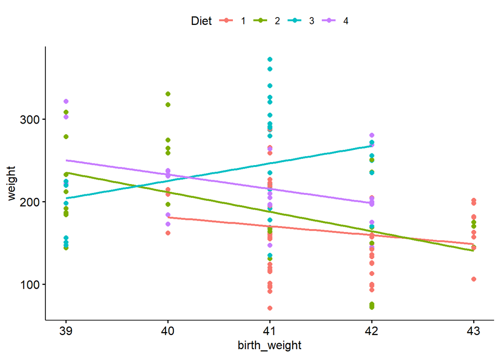

```r
#linearity
ggscatter(all_days, x="birth_weight", y="weight", color="Diet", add="reg.line")
```

```r
#homogeneity
all_days %>% anova_test(weight ~ Diet*birth_weight)
```

```
## ANOVA Table (type II tests)
##
##              Effect DFn DFd      F        p p<.05   ges
## 1              Diet   3 130 10.085 5.08e-06     * 0.189
## 2      birth_weight   1 130  5.984 1.60e-02     * 0.044
## 3 Diet:birth_weight   3 130  4.357 6.00e-03     * 0.091
```

```r
#normally distributed
model <- lm(weight~birth_weight+Diet, data = all_days)
model.metrics <- augment(model) %>% select(-.hat,-.sigma,-.fitted)
head(model.metrics, 3)
```

```
## # A tibble: 3 × 6
##   weight birth_weight Diet  .resid  .cooksd .std.resid
##    <dbl>        <dbl> <fct>  <dbl>    <dbl>      <dbl>
## 1    149           42 1      -10.4 0.000141     -0.180
## 2    162           40 1      -19.5 0.000881     -0.342
## 3    163           43 1       14.7 0.000456      0.258
```

```r
shapiro_test(model.metrics$.resid)
```

```
## # A tibble: 1 × 3
##   variable             statistic p.value
##   <chr>                    <dbl>   <dbl>
## 1 model.metrics$.resid     0.984   0.105
```

```r
#homoscedasticity
model.metrics %>% levene_test(.resid~Diet)
```

```
## # A tibble: 1 × 4
##     df1   df2 statistic       p
##   <int> <int>     <dbl>   <dbl>
## 1     3   134      4.70 0.00374
```

```r
#outliers
model.metrics %>% filter(abs(.std.resid) > 3) %>% as.data.frame()
```

```
## [1] weight       birth_weight Diet         .resid       .cooksd
## [6] .std.resid
## <0 rows> (or 0-length row.names)
```

The data seems to satisfy a majority of the assumptions for ANCOVA. Two assumptions not surely satisfied include linearity of covariate and outcome variable, and homoscedasticity. The Levene test resulted in a statistically significant p-value, therefore homogeneity between the residuals must be questioned. The scatter plot of covariate and outcome variable does show a linear relationship between the two variables, however, the linear relationship has opposite signs for different diet groups, so further investigation here may be necessary. In the test for homogeneity we have a p-value for the interaction term that is statistically significant at the 0.05 level, which suggests this assumption may actually be violated as well, and this could provide some explanation for the opposite slopes we see in the previous plot.

2. Checking assumptions of repeated measures ANOVA (1:No outliers, 2:Normality of outcome, sphericity)

```r
#outliers
outliers <- chick2 %>% group_by(Time) %>% identify_outliers(weight)
data.frame(outliers)
```

```
##   Time Chick weight Diet is.outlier is.extreme
## 1    0    27     39    2       TRUE      FALSE
## 2    0    28     39    2       TRUE      FALSE
## 3    0    29     39    2       TRUE      FALSE
## 4    0    33     39    3       TRUE      FALSE
## 5    0    36     39    3       TRUE      FALSE
## 6    0    48     39    4       TRUE      FALSE
## 7   16    35    287    3       TRUE      FALSE
```

```r
#normality
normal <- chick2 %>% group_by(Time) %>% shapiro_test(weight)
data.frame(normal)
```

```
##   Time variable statistic            p
## 1    0   weight 0.8967456 0.0007515011
## 2   16   weight 0.9837277 0.7709228377
## 3   20   weight 0.9912299 0.9799094812
## 4   21   weight 0.9864017 0.8691427524
```

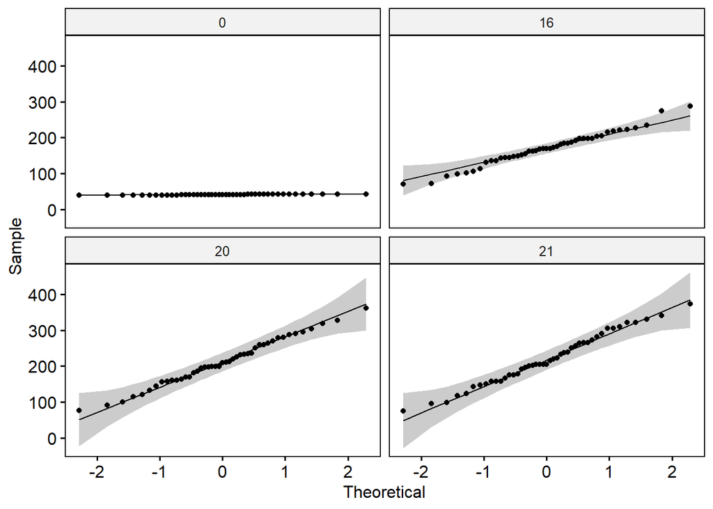

```r
ggqqplot(chick2, "weight", facet.by="Time")
```

```r
#sphericity
get_anova_table(repeated.aov)
```

```
##
## Call:
## aov(formula = chick2$weight ~ chick2$Diet * chick2$Time + Error(factor(chick2$Chick)))
##
## Grand Mean: 160.2222
##
## Stratum 1: factor(chick2$Chick)
##
## Terms:
##                 chick2$Diet Residuals
## Sum of Squares     90340.49 273869.12
## Deg. of Freedom           3        41
##
## Residual standard error: 81.72964
## 9 out of 12 effects not estimable
## Estimated effects may be unbalanced
##
## Stratum 2: Within
##
## Terms:
##                 chick2$Time chick2$Diet:chick2$Time Residuals
## Sum of Squares     915424.7                 37041.0  114345.8
## Deg. of Freedom           3                       9       123
##
## Residual standard error: 30.49002
## Estimated effects may be unbalanced
```